[figure not shown]

Introduction to Statistical Thinking and Data Analysis, MSc Epidemiology and MSc Health Data Analytics 2019

# Session 3: Data visualisation

Dr Juliette Unwin

23rd October 2019

Today’s session will cover data visualisation using

- base R
- ggplot

and is based on data visualisation chapter in R for Data Science by Gorlemund and Wickham.

What do you remember from last week?

https://forms.gle/asekqiTJRPyHK7gB9

[figure not shown]

## Exploring the test data set

```r
library(tidyverse)
## ── Attaching packages ────────────────────────────────────────────────────────────── tidyverse 1.2.1 ──
## ✔ ggplot2 3.2.0     ✔ purrr   0.3.2
## ✔ tibble  2.1.3     ✔ dplyr   0.8.1
## ✔ tidyr   0.8.3     ✔ stringr 1.4.0
## ✔ readr   1.3.1     ✔ forcats 0.4.0
## ── Conflicts ───────────────────────────────────────────────────────────────── tidyverse_conflicts() ──
## ✖ dplyr::filter() masks stats::filter()
## ✖ dplyr::lag()    masks stats::lag()
mpg
## # A tibble: 234 x 11
##    manufacturer model displ  year   cyl trans drv     cty   hwy fl    class
##    <chr>        <chr> <dbl> <int> <int> <chr> <chr> <int> <int> <chr> <chr>
##  1 audi         a4      1.8  1999     4 auto… f        18    29 p     comp…
##  2 audi         a4      1.8  1999     4 manu… f        21    29 p     comp…
##  3 audi         a4      2    2008     4 manu… f        20    31 p     comp…
##  4 audi         a4      2    2008     4 auto… f        21    30 p     comp…
##  5 audi         a4      2.8  1999     6 auto… f        16    26 p     comp…
##  6 audi         a4      2.8  1999     6 manu… f        18    26 p     comp…
##  7 audi         a4      3.1  2008     6 auto… f        18    27 p     comp…
##  8 audi         a4 q…   1.8  1999     4 manu… 4        18    26 p     comp…
##  9 audi         a4 q…   1.8  1999     4 auto… 4        16    25 p     comp…
## 10 audi         a4 q…   2    2008     4 manu… 4        20    28 p     comp…
## # … with 224 more rows

head(mpg)
## # A tibble: 6 x 11
##   manufacturer model displ  year   cyl trans  drv     cty   hwy fl    class
##   <chr>        <chr> <dbl> <int> <int> <chr>  <chr> <int> <int> <chr> <chr>
## 1 audi         a4      1.8  1999     4 auto(… f        18    29 p     comp…
## 2 audi         a4      1.8  1999     4 manua… f        21    29 p     comp…
## 3 audi         a4      2    2008     4 manua… f        20    31 p     comp…
## 4 audi         a4      2    2008     4 auto(… f        21    30 p     comp…
## 5 audi         a4      2.8  1999     6 auto(… f        16    26 p     comp…
## 6 audi         a4      2.8  1999     6 manua… f        18    26 p     comp…
```

## Plotting with base R

## Scatter plots

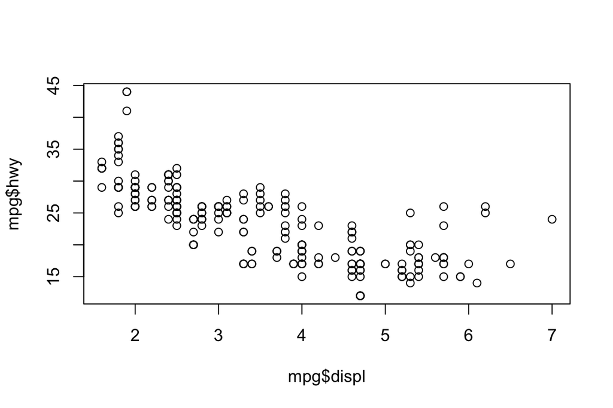

```r
plot(mpg$displ, mpg$hwy)
```

```r
# What else is needed to make this a good plot?
# Titles

# Grid lines

# Specifying shape of points - ?pch

# Specifying colour of points

# Adding legend
```

## Line plots

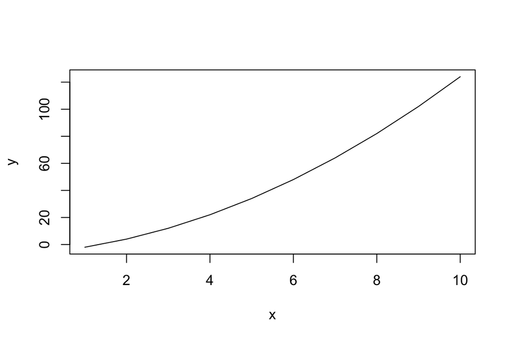

```r
x <- 1:10
y <- x^2 + 3*x - 6
plot(x, y, type = 'l')
```

```r
# Adding a second line

# Line weight - lwd

# Line style - lty
```

## Line plots - line styles

- 0: blank,
- 1: solid (default)
- 2: dashed
- 3: dotted
- 4: dotdash
- 5: longdash
- 6: twodash.

## Scatter graph with trend lines

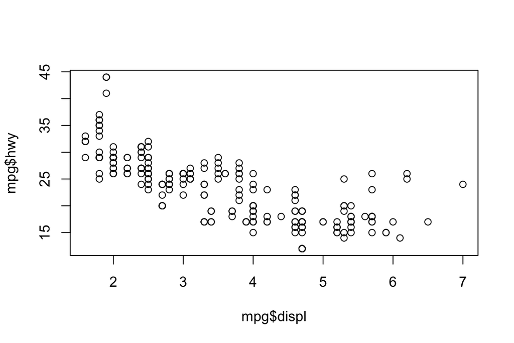

```r
plot(mpg$displ, mpg$hwy)
```

## Linear models

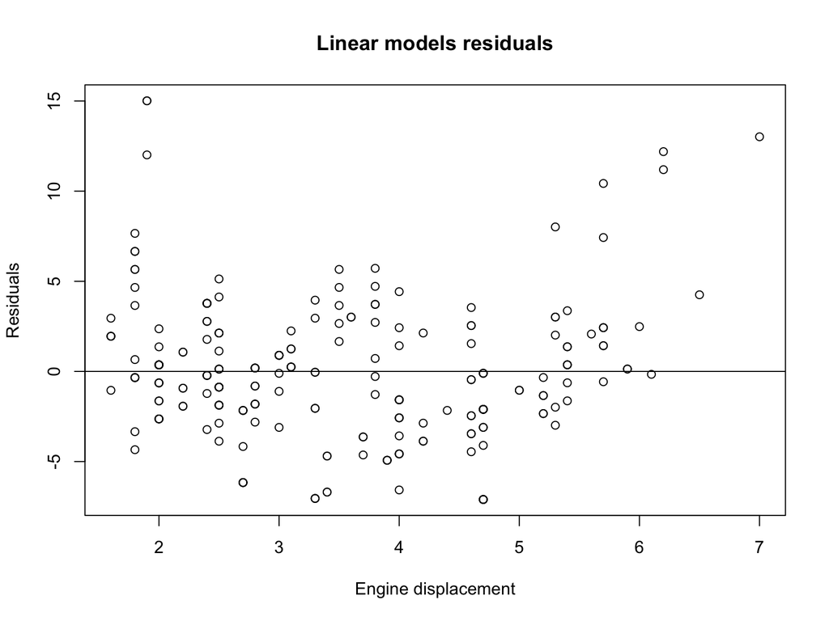

```r
linear_model <- lm(mpg$hwy ~ mpg$displ)
linear_model_residual <- resid(linear_model)

plot(mpg$displ, linear_model_residual,
     ylab="Residuals", xlab="Engine displacement",
     main="Linear models residuals")
abline(0, 0)
```

```r
help(resid)
```

## Bar graph

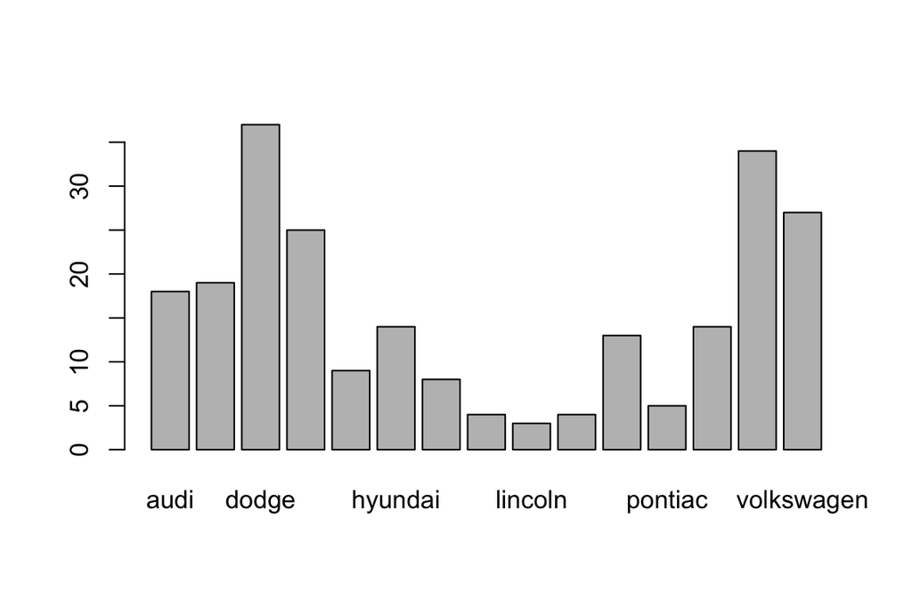

```r
# Making a bar graph for the different numbers of cars from each manufacturer
count <- table(mpg$manufacturer)
barplot(count)
```

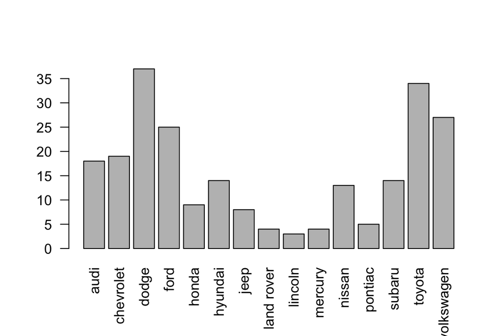

```r
# Rotating axis names
barplot(count, las=2)
```

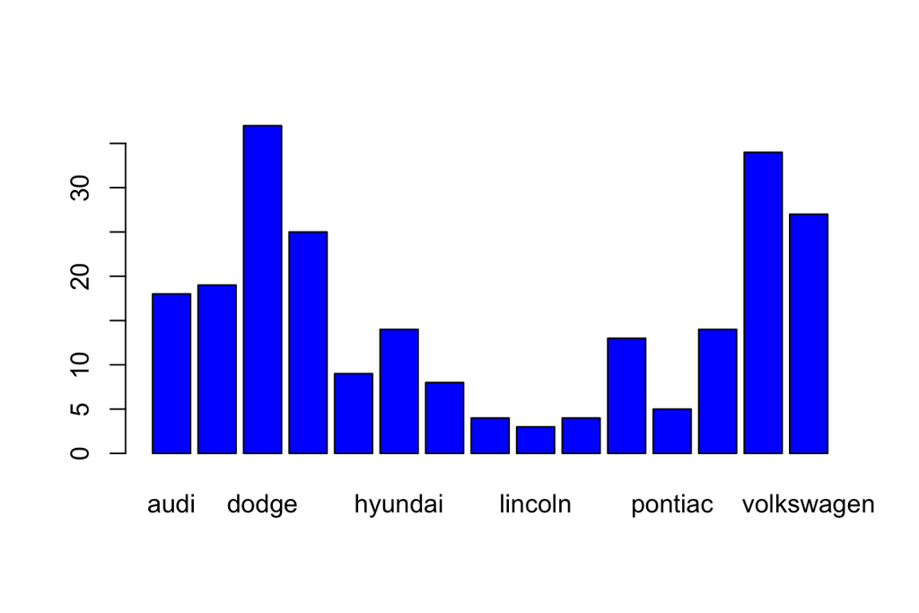

```r
# Changing colours
barplot(count, col="blue")
```

## Plotting bar graphs side by side

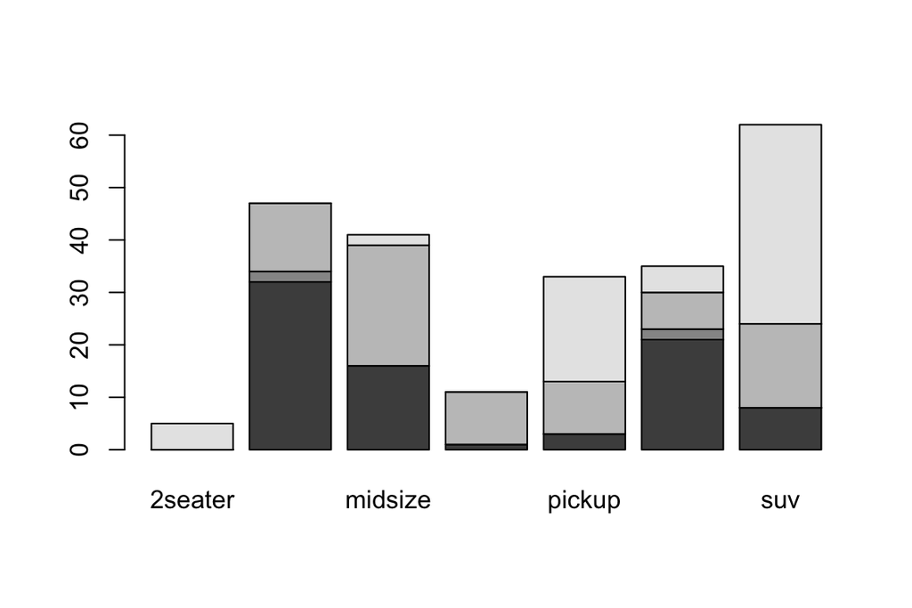

```r
table <- table(mpg$cyl, mpg$class, dnn=c("Cylinders", "Class")) # Creates a contingency table
table
##          Class
## Cylinders 2seater compact midsize minivan pickup subcompact suv
##         4       0      32      16       1      3         21   8
##         5       0       2       0       0      0          2   0
##         6       0      13      23      10     10          7  16
##         8       5       0       2       0     20          5  38

# Stacked
barplot(table)
```

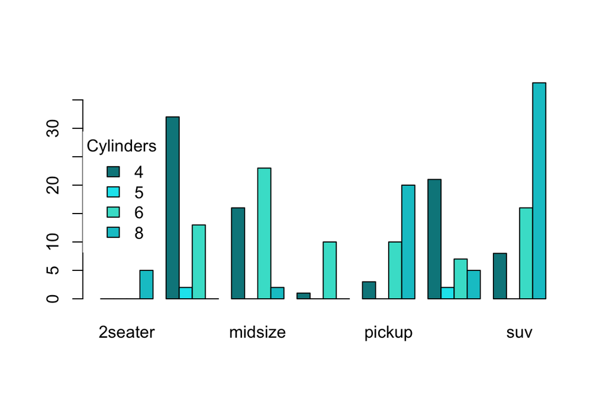

```r
# Sidebyside
barplot(table,
        col = c("turquoise4", "turquoise2", "turquoise", "turquoise3"),
        beside=TRUE)

legend("left", title="Cylinders",
       legend = sort(unique(mpg$cyl)),
       fill =c("turquoise4", "turquoise2", "turquoise", "turquoise3"),
       box.lty=0)
```

## Histograms

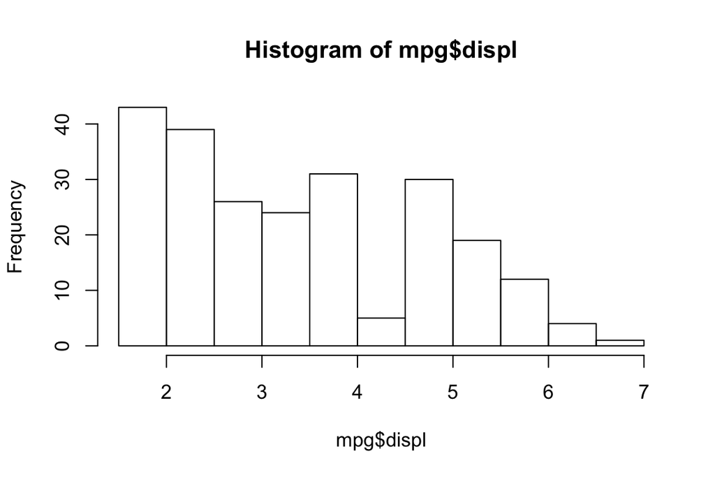

```r
hist(mpg$displ)
```

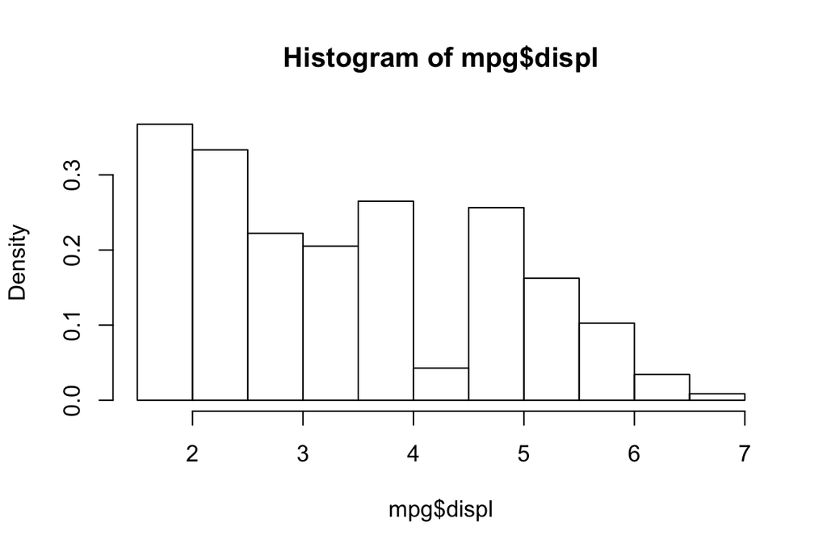

```r
# Normalising histogram
hist(mpg$displ, freq=FALSE)
```

```r
# Changing size of bins


# Looking at information about histograms
```

## Vertical and horizontal lines

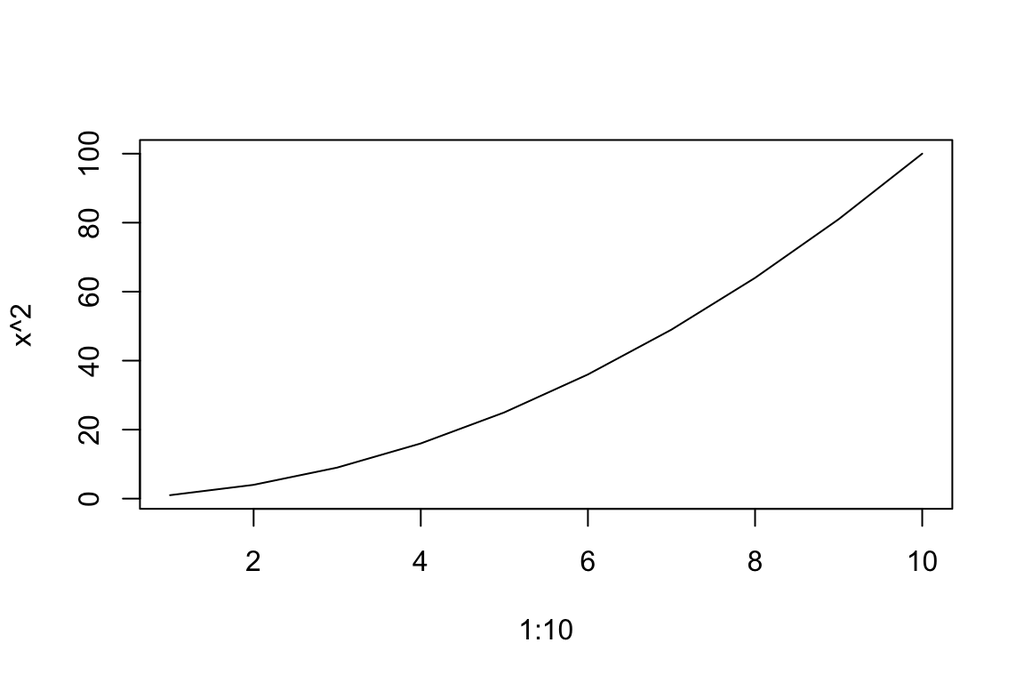

```r
plot(x = 1:10, y = x^2, type = 'l')
```

## Multiple plots

```r
par(mfrow=c(1,2))
```

## Plotting with ggplot

Plotting with ggplot isn’t like plotting with plot.

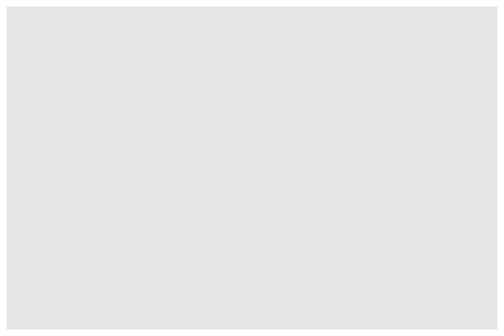

```r
library(ggplot2)
ggplot(mpg)
```

## Plotting with ggplot

```
ggplot(data = <DATA>) +
  <GEOM_FUNCTION>(mapping = aes(<MAPPINGS>))
```

```r
# Plot displ against hwy with col displ
```

## Some of the different aesthetics

- x - x values
- y - y values
- shape - changes the shape of points depending on variable
- col - changes the colour of points depending on variable
- alpha - changes the transparancy of points depending on variable

## Some useful geoms

- geom_point - scatter graph
- geom_line - line graph
- geom_vline, geom_hline, geom_abline - straight lines
- geom_bar - bar graph
- geom_histogram - histogram

https://rstudio.com/wp-content/uploads/2015/03/ggplot2-cheatsheet.pdf

## A few examples - well presented graph

```r
# Plot displ against hwy with col displ
# Limits labels
```

## A few examples - line graph

```r
x <- 1:10
y <- x^2 + 3*x - 6
y2 <- - x^2 - 3*x + 52

df <- data.frame("x" = x, "y" = y, "y2" = y2)
```

```r
# histogram of displ
```

## Themes

Can change the theme of graphs to make them look more to your taste

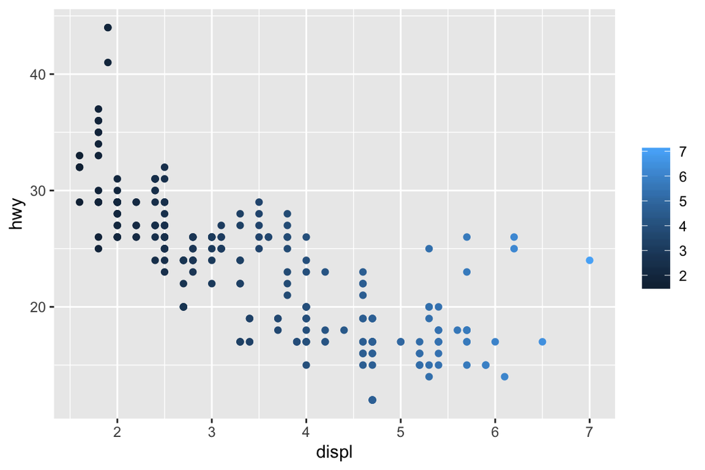

```r
p <- ggplot(data = mpg) +
  geom_point(aes(x = displ, y = hwy, col = displ))

p + theme(legend.title = element_blank())
```

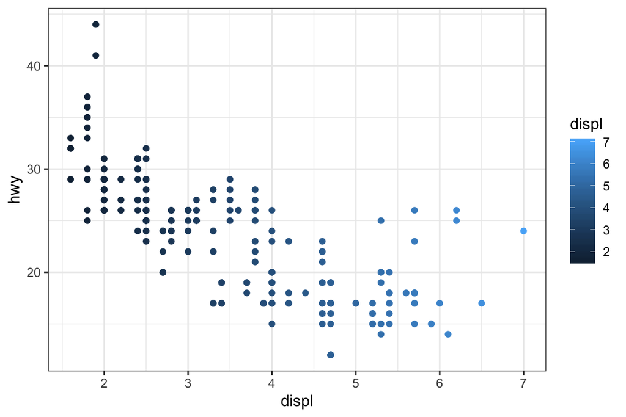

```r
p + theme_bw()
```

## Multiple plots using cowplot

```r
library(cowplot)
p1 <- ggplot(data = mpg) +
  geom_point(aes(x = displ, y = hwy, col = displ))
p2 <- ggplot(data = mpg) +
  geom_point(aes(x = displ, y = hwy, col = displ))
```

## Summary

- Base r and qplot are generally thought to be easier to use.
- ggplot2 is more flexible and can make nicer plots visually.
- Which you use is up to you and sometimes one may be better than the other.